# Homework 03

## Question 1: Build an `explain-to-me` skill

Create a small skill named `explain-to-me` that helps you understand a homework question.

1. Design your `SKILL.md` file so that, when you explicitly ask your agent to use the skill to read a homework question, the agent communicates with you and explains what the question is asking.
2. Keep the skill file short. It should contain a few useful rules, instructions, and a clear statement of your intent. For example, you may ask the agent to explain the goal of the question, clarify what work is required, and point you to an appropriate section of the Week 3 lectures: [Ridge Regression: Stability Through Shrinkage](https://teazrq.github.io/stat432rpy/topics/ridge-regression/ridge-regression.html) or [From a Penalized Objective to a Fitted Ridge Model](https://teazrq.github.io/stat432rpy/topics/ridge-regression/optimization-and-cross-validation.html). The skill should help you understand the question without completing the solution for you.
3. Create the skill yourself or with the help of AI. Save it as `explain-to-me/SKILL.md`. Then ask your AI agent to install the skill using its normal skill-installation method. Test it by explicitly asking the agent to use `explain-to-me` to read and explain Question 2.
4. If the skill does not work well, or if it begins to disturb your usual workflow, ask your agent to remove the installed skill. You may revise and reinstall it if you wish.
5. In all cases, append the complete contents of your developed `explain-to-me/SKILL.md` file at the end of your Homework 3 submission under the heading **`explain-to-me` skill**.

## Question 2: Ridge regression with nearly collinear predictors

Let $n=100$. Generate mutually independent standard normal random variables

$$L_i, U_{i1}, U_{i2}, X_{i3}, X_{i4},
\qquad i=1,\ldots,n,$$

and define

$$X_{i1}=L_i+0.04U_{i1},
\qquad
X_{i2}=L_i+0.04U_{i2}.$$

Center and standardize each column of $\mathbf X$ to have mean zero and average squared value one, following the [lecture’s scaling convention](https://teazrq.github.io/stat432rpy/topics/ridge-regression/ridge-regression.html#put-every-covariate-on-a-common-scale).

Continue to use $\mathbf X\in\mathbb R^{n\times p}$ for the standardized matrix and keep it fixed throughout the question, where $p=4$ is the number of predictors. The unpenalized intercept gives $p+1=5$ total fitted coefficients. Let

$$\boldsymbol\beta
=
(1.5,1.5,1,0)^{\mathsf T},
\qquad
\boldsymbol\mu
=
\mathbf X\boldsymbol\beta.$$

Generate a training response and an independent test response at the same predictor values:

$$\begin{aligned}
\mathbf y
&=
\boldsymbol\mu+\boldsymbol\epsilon,\\
\mathbf y^*
&=
\boldsymbol\mu+\boldsymbol\epsilon^*,
\end{aligned}$$

where

$$\boldsymbol\epsilon,
\boldsymbol\epsilon^*
\overset{\mathrm{ind}}{\sim}
\mathcal N_n(\mathbf0,\mathbf I_n).$$

Center the training response as $\widetilde{\mathbf y}=\mathbf y-\bar y\mathbf1_n$. For each $\lambda\in\{0,0.02,0.2\}$, fit the slopes using the lecture’s ridge formula:

$$\widehat{\boldsymbol\beta}_\lambda
=
\left(\mathbf X^{\mathsf T}\mathbf X+n\lambda\mathbf I_p\right)^{-1}
\mathbf X^{\mathsf T}\widetilde{\mathbf y}.$$

The unpenalized intercept is $\widehat\beta_0=\bar y$; add this training mean back when predicting either response. The case $\lambda=0$ is ordinary least squares. Use seed `43231` before generating the design and responses. R and Python use different random-number generators, so their exact numerical results need not agree.

1. Generate $\mathbf X$ once. Report the correlation between its first two columns and its largest and smallest singular values. Use these quantities to explain why the estimator contrast $\widehat\beta_1-\widehat\beta_2$ should be much more variable than $\widehat\beta_1+\widehat\beta_2$.
2. Independently repeat the generation of $\mathbf y$ and $\mathbf y^*$, followed by all three fits, 200 times while keeping $\mathbf X$ fixed. Draw the training and test noise inside each repetition, then reuse that realized pair for all three values of $\lambda$. For each value of $\lambda$, report the empirical mean and standard deviation of

$$\widehat\beta_1,
\quad
\widehat\beta_2,
\quad
\widehat\beta_1+\widehat\beta_2,
\quad
\widehat\beta_1-\widehat\beta_2.$$

Also report the average training MSE and the average test MSE calculated from the independent test response, where

$$\operatorname{MSE}_{\mathrm{test}}
=
\frac{1}{n}
\left\lVert
\mathbf y^*
-
\widehat\beta_0\mathbf1_n
-
\mathbf X\widehat{\boldsymbol\beta}
\right\rVert_2^2.$$

3. Interpret the coefficient estimates and test MSE using bias and variance. Explain why ridge can substantially stabilize the individual coefficients without producing an equally large change in the fitted values.

**Show the workflow**

```python
import numpy as np

rng = np.random.default_rng(43231)
n = 100
p = 4
lambdas = [0.0, 0.02, 0.2]
repetitions = 200

L = rng.normal(size=n)
U1 = rng.normal(size=n)
U2 = rng.normal(size=n)
X3 = rng.normal(size=n)
X4 = rng.normal(size=n)

X1 = L + 0.04 * U1
X2 = L + 0.04 * U2
X_raw = np.column_stack([X1, X2, X3, X4])

# Center and standardize each column: mean 0, average squared value 1
# (divide by population std, i.e. ddof=0 -- "the lecture's scaling convention").
X_centered = X_raw - X_raw.mean(axis=0)
scales = np.sqrt((X_centered ** 2).mean(axis=0))
X = X_centered / scales

beta_true = np.array([1.5, 1.5, 1.0, 0.0])
mu = X @ beta_true


def ridge_fit(X, y, lam):
    """Return (beta0_hat, beta_hat) using the lecture's ridge formula."""
    y_bar = y.mean()
    y_tilde = y - y_bar
    beta_hat = np.linalg.solve(X.T @ X + n * lam * np.eye(p), X.T @ y_tilde)
    beta0_hat = y_bar
    return beta0_hat, beta_hat

corr_12 = np.corrcoef(X[:, 0], X[:, 1])[0, 1]
singular_values = np.linalg.svd(X, compute_uv=False)

print("=== Part (a) ===")
print(f"Correlation between column 1 and column 2: {corr_12:.4f}")
print(f"Largest singular value:  {singular_values.max():.4f}")
print(f"Smallest singular value: {singular_values.min():.4f}")
```

```
=== Part (a) ===
Correlation between column 1 and column 2: 0.9983
Largest singular value:  14.1730
Smallest singular value: 0.4061
```

With X1 and X2 both built from the same shared signal L (plus tiny independent noise), they’re almost the same column — my run gives correlation ≈ 0.998, largest singular value ≈ 14.2, smallest ≈ 0.41. A large singular value means there’s a well-observed direction in the data (roughly x₁+x₂, since both move together); a tiny singular value means there’s almost no information in the direction x₁−x₂, since that difference is nearly zero for every observation. Because β̂₁−β̂₂ is estimated almost entirely from that starved, near-zero direction, tiny amounts of noise get wildly amplified in the difference — while β̂₁+β̂₂ is estimated from the strong, well-observed direction and stays stable.

**Show the workflow**

```python
results = {lam: {"beta1": [], "beta2": [], "sum": [], "diff": [],
                  "train_mse": [], "test_mse": []} for lam in lambdas}

for _ in range(repetitions):
    eps = rng.normal(size=n)
    eps_star = rng.normal(size=n)
    y = mu + eps
    y_star = mu + eps_star

    for lam in lambdas:
        beta0_hat, beta_hat = ridge_fit(X, y, lam)
        y_hat = beta0_hat + X @ beta_hat

        results[lam]["beta1"].append(beta_hat[0])
        results[lam]["beta2"].append(beta_hat[1])
        results[lam]["sum"].append(beta_hat[0] + beta_hat[1])
        results[lam]["diff"].append(beta_hat[0] - beta_hat[1])
        results[lam]["train_mse"].append(np.mean((y - y_hat) ** 2))
        results[lam]["test_mse"].append(np.mean((y_star - y_hat) ** 2))

print("\n=== Part (b) ===")
print(f"{'lambda':>7}  {'beta1 mean(sd)':>16}  {'beta2 mean(sd)':>16}  "
      f"{'sum mean(sd)':>16}  {'diff mean(sd)':>16}")
for lam in lambdas:
    r = results[lam]
    print(
        f"{lam:7.2f}  "
        f"{np.mean(r['beta1']):6.3f}({np.std(r['beta1']):5.3f})   "
        f"{np.mean(r['beta2']):6.3f}({np.std(r['beta2']):5.3f})   "
        f"{np.mean(r['sum']):6.3f}({np.std(r['sum']):5.3f})   "
        f"{np.mean(r['diff']):6.3f}({np.std(r['diff']):5.3f})"
    )

print(f"\n{'lambda':>7}  {'avg train MSE':>14}  {'avg test MSE':>14}")
for lam in lambdas:
    r = results[lam]
    print(f"{lam:7.2f}  {np.mean(r['train_mse']):14.3f}  {np.mean(r['test_mse']):14.3f}")
```

```
=== Part (b) ===
 lambda    beta1 mean(sd)    beta2 mean(sd)      sum mean(sd)     diff mean(sd)
   0.00   1.290(1.791)    1.701(1.793)    2.992(0.105)   -0.411(3.583)
   0.02   1.465(0.144)    1.497(0.148)    2.961(0.104)   -0.032(0.273)
   0.20   1.355(0.049)    1.359(0.050)    2.715(0.095)   -0.004(0.029)

 lambda   avg train MSE    avg test MSE
   0.00           0.949           1.038
   0.02           0.960           1.029
   0.20           1.064           1.125
```

At λ=0, β̂₁ and β̂₂ average 1.29 and 1.70 with sd≈1.79 each; their sum averages 2.99 (sd 0.10) but their difference averages −0.41 (sd 3.58) — hugely unstable given the true difference is 0. At λ=0.02, individual sds drop to ~0.14–0.15 and the difference’s sd falls to 0.27, while the sum barely moves (2.96). At λ=0.2, individual sds shrink further (~0.05) but the sum drops to 2.715, below its true value of 3.0. Training/test MSE: OLS gives 0.949/1.038, λ=0.02 gives 0.960/1.029 (best test MSE), λ=0.2 gives 1.064/1.125 (worst).

3. λ=0.02 mainly cuts variance with little bias cost — coefficient sds fall 10x+ while the sum stays accurate — so it improves test MSE over OLS. λ=0.2 over-penalizes: the sum becomes biased (2.715 vs 3.0), and that bias now outweighs the variance savings, making test MSE worse than both other choices. Fitted values barely move across λ because ridge shrinks directions unevenly: x₁−x₂ carries almost no signal (singular value 0.41) so it gets crushed, stabilizing β̂₁ and β̂₂ individually, while x₁+x₂ is strong (singular value 14.17) and stays nearly untouched — and since predictions depend mainly on that strong direction, ŷ stays stable even as the individual coefficients change a lot.

## Question 3: What does ridge regression shrink?

Let $\mathbf X\in\mathbb R^{n\times p}$ be a centered predictor matrix, and let $\widetilde{\mathbf y}\in\mathbb R^n$ be the centered response. Use the supplied predictor scales for this algebraic question; the columns need not have unit variance. Here $p$ counts predictors, $\boldsymbol\beta\in\mathbb R^p$ contains their slopes, and $p+1$ counts all fitted coefficients, including the separately fitted, unpenalized intercept. Ridge regression minimizes

$$L_\lambda(\boldsymbol\beta)
=
\frac{1}{2n}
\left\lVert
\widetilde{\mathbf y}-\mathbf X\boldsymbol\beta
\right\rVert_2^2
+
\frac{\lambda}{2}
\lVert\boldsymbol\beta\rVert_2^2.$$

1. Derive the ridge normal equation

$$\left(
\mathbf X^{\mathsf T}\mathbf X
+n\lambda\mathbf I_p
\right)
\widehat{\boldsymbol\beta}_\lambda
=
\mathbf X^{\mathsf T}\widetilde{\mathbf y}.$$

Explain why it has a unique solution whenever $\lambda>0$, even if $\mathbf X$ is rank deficient or $p>n$.

2. Let

$$\mathbf X
=
\mathbf U_r\mathbf D_r\mathbf V_r^{\mathsf T}$$

be a compact singular value decomposition, where $r=\operatorname{rank}(\mathbf X)$, $\mathbf U_r\in\mathbb R^{n\times r}$, $\mathbf D_r\in\mathbb R^{r\times r}$, and $\mathbf V_r\in\mathbb R^{p\times r}$. Show that ridge multiplies the fitted response component in the $j$th left singular-vector direction, for $j=1,\ldots,r$, by

$$\rho_j(\lambda)
=
\frac{d_j^2}{d_j^2+n\lambda}.$$

Suppose $n=100$, $\lambda=0.01$, and the nonzero singular values are

$$d_1=10,
\qquad
d_2=2,
\qquad
d_3=0.2.$$

Calculate the three shrinkage factors and the total effective degrees of freedom, including the unpenalized intercept:

$$\operatorname{df}_{\mathrm{eff}}(\lambda)
=
1+\sum_{j=1}^3\rho_j(\lambda).$$

3. Which direction receives the strongest shrinkage? Explain why shrinking this direction can reduce prediction variance. Under what circumstance could the same shrinkage produce substantial prediction bias?
4. Ridge minimizes L_λ(β) = (1/2n)‖ỹ − Xβ‖² + (λ/2)‖β‖². Taking the gradient and setting it to zero:

∇L_λ(β) = −(1/n)Xᵀ(ỹ − Xβ) + λβ = 0 ⟹ (1/n)XᵀXβ̂_λ + λβ̂_λ = (1/n)Xᵀỹ ⟹ (XᵀX + nλI_p)β̂_λ = Xᵀỹ

For any nonzero a ∈ ℝᵖ: aᵀ(XᵀX + nλI_p)a = ‖Xa‖² + nλ‖a‖² > 0 whenever λ>0, since the second term is strictly positive even if Xa = 0 (i.e., even if XᵀX is singular because X is rank-deficient or p>n). A matrix that’s positive definite for every nonzero a is invertible, so the solution β̂_λ = (XᵀX + nλI_p)⁻¹Xᵀỹ always exists and is unique — unlike OLS, which fails whenever XᵀX is singular.

2. Write X = U_r D_r V_rᵀ (compact SVD, rank r). Substituting into the normal equation and simplifying (using U_rᵀU_r = I_r, V_rᵀV_r = I_r) gives β̂_λ = V_r(D_r² + nλI_r)⁻¹D_rU_rᵀỹ. Multiplying by X = U_rD_rV_rᵀ:

Xβ̂_λ = Σⱼ₌₁ʳ [dⱼ²/(dⱼ²+nλ)] uⱼuⱼᵀỹ

So the fitted response’s component along each left singular direction uⱼ gets scaled by ρⱼ(λ) = dⱼ²/(dⱼ²+nλ) — this is exactly the ridge “filter factor.” (If r<p, directions orthogonal to V_r are in X’s null space; ridge sets those coefficient components to zero since they’d only add penalty without changing any fitted value.)

**Show the workflow**

```python
import numpy as np
n = 100
lam = 0.01
d = np.array([10.0, 2.0, 0.2])  # nonzero singular values d1, d2, d3

rho = d**2 / (d**2 + n * lam)
df_eff = 1 + rho.sum()  # "+1" accounts for the unpenalized intercept

print("=== Part (c) ===")
for j, r in enumerate(rho, start=1):
    print(f"rho_{j} = {r:.4f}")
print(f"df_eff(lambda={lam}) = {df_eff:.4f}")
print(f"Strongest shrinkage: direction {np.argmin(rho) + 1} (rho = {rho.min():.4f})")
```

```
=== Part (c) ===
rho_1 = 0.9901
rho_2 = 0.8000
rho_3 = 0.0385
df_eff(lambda=0.01) = 2.8286
Strongest shrinkage: direction 3 (rho = 0.0385)
```

With n=100, λ=0.01 (so nλ=1) and d₁=10, d₂=2, d₃=0.2:

ρ₁ = 100/101 ≈ 0.9901, ρ₂ = 4/5 = 0.8000, ρ₃ = 0.04/1.04 ≈ 0.0385

df_eff(0.01) = 1 + 0.9901 + 0.8 + 0.0385 ≈ 2.8286 (the leading “+1” is the unpenalized intercept).

Direction 3 gets the strongest shrinkage (ρ₃≈0.0385, keeping under 4% of its OLS value). That direction has the smallest singular value, meaning the data carry very little information there — an unregularized fit along that direction is highly sensitive to noise (small denominator effects blow up variance), so shrinking it toward zero removes a lot of variance cheaply. The risk: if the true signal actually has a substantial component along that same weak direction, shrinking it to ~3.85% of its OLS value would cut out real signal, not just noise — producing significant bias rather than a pure variance win.

## Question 4: Ridge regression and optimization

Let $\mathbf X\in\mathbb R^{n\times p}$ be a centered predictor matrix with $p=2$. Its columns need not have unit variance in this question. The intercept is fitted separately and is not penalized. Suppose the two eigenvalues of

$$\mathbf A_0
=
\frac{1}{n}\mathbf X^{\mathsf T}\mathbf X$$

are $9$ and $0.01$. Ridge regression with $\lambda=0.09$ has curvature matrix

$$\mathbf A_\lambda
=
\frac{1}{n}\mathbf X^{\mathsf T}\mathbf X
+
\lambda\mathbf I_p.$$

1. Calculate the condition numbers of $\mathbf A_0$ and $\mathbf A_\lambda$. Explain what the change says about the geometry of the ridge objective.
2. Gradient descent uses

$$\boldsymbol\beta^{(k+1)}
=
\boldsymbol\beta^{(k)}
-
\eta\nabla L_\lambda\!\left(\boldsymbol\beta^{(k)}\right).$$

Let $\widehat{\boldsymbol\beta}_\lambda$ be the ridge minimizer and define the optimization error

$$\mathbf e^{(k)}
=
\boldsymbol\beta^{(k)}
-
\widehat{\boldsymbol\beta}_\lambda.$$

Show that the component of $\mathbf e^{(k)}$ in an eigendirection with unpenalized eigenvalue $a$ is multiplied at each step by

$$1-\eta(a+\lambda).$$

Let $M=9.09$, the largest eigenvalue of $\mathbf A_\lambda$. Find the interval of step sizes that contracts every eigendirection. Then compare these two choices:

- For $\eta=1/M$, calculate the two contraction factors and explain which direction converges faster.
- For $\eta=2.1/M$, determine whether the method converges. Assume the initial error has a nonzero component in the eigendirection corresponding to $M$.
3. Increasing $\lambda$ generally improves the condition number. Explain why choosing $\lambda$ to make gradient descent converge as quickly as possible is not a valid statistical tuning rule.

**Show the workflow**

```python
import numpy as np

# ============================================================
# Part (a): condition numbers of A0 and A_lambda
# ============================================================
eig_A0 = np.array([9.0, 0.01])
lam = 0.09
eig_Alam = eig_A0 + lam  # ridge adds lambda to every eigenvalue

kappa_A0 = eig_A0.max() / eig_A0.min()
kappa_Alam = eig_Alam.max() / eig_Alam.min()

print("=== Part (a) ===")
print(f"Eigenvalues of A0:      {eig_A0}")
print(f"Eigenvalues of A_lambda: {eig_Alam}")
print(f"condition number kappa(A0)      = {kappa_A0:.1f}")
print(f"condition number kappa(A_lambda) = {kappa_Alam:.2f}")
```

```
=== Part (a) ===
Eigenvalues of A0:      [9.   0.01]
Eigenvalues of A_lambda: [9.09 0.1 ]
condition number kappa(A0)      = 900.0
condition number kappa(A_lambda) = 90.90
```

κ(A₀) = 9/0.01 = 900. Ridge adds λ=0.09 to every eigenvalue: eigenvalues become 9.09 and 0.10, so κ(A_λ) = 9.09/0.10 = 90.9. The objective’s contours go from extremely elongated (κ=900, nearly a ravine) to much more circular (κ=90.9) — ridge doesn’t just penalize size, it also makes the loss surface far better-conditioned for optimization.

2. Since the ridge objective is quadratic, ∇L_λ(β^(k)) = A_λe^(k) where e^(k) = β^(k) − β̂_λ. So the gradient descent update becomes:

e^(k+1) = e^(k) − ηA_λe^(k) = (I_p − ηA_λ)e^(k)

In an eigendirection where A_λ has eigenvalue (a+λ), that component of e^(k) is multiplied by the corresponding eigenvalue of (I_p − ηA_λ), which is 1 − η(a+λ) — exactly the stated factor.

**Show the workflow**

```python
M = eig_Alam.max()  # largest eigenvalue of A_lambda = 9.09
eta_bound = 2 / M

print("\n=== Part (b) step-size comparison ===")
print(f"M = {M:.4f}")
print(f"Contraction requires 0 < eta < 2/M = {eta_bound:.4f}")

for eta_label, eta in [("1/M", 1 / M), ("2.1/M", 2.1 / M)]:
    factors = 1 - eta * eig_Alam
    print(f"\neta = {eta_label} = {eta:.5f}")
    for a, f in zip(eig_Alam, factors):
        print(f"  eigenvalue {a:.2f}: contraction factor = {f:.4f} "
              f"({'contracts' if abs(f) < 1 else 'DIVERGES'})")
```

```
=== Part (b) step-size comparison ===
M = 9.0900
Contraction requires 0 < eta < 2/M = 0.2200

eta = 1/M = 0.11001
  eigenvalue 9.09: contraction factor = 0.0000 (contracts)
  eigenvalue 0.10: contraction factor = 0.9890 (contracts)

eta = 2.1/M = 0.23102
  eigenvalue 9.09: contraction factor = -1.1000 (DIVERGES)
  eigenvalue 0.10: contraction factor = 0.9769 (contracts)
```

Every direction contracts when |1−η(a+λ)|<1 for all eigenvalues; since M=9.09 is the largest, this reduces to 0 < η < 2/M ≈ 0.2200.

For η=1/M≈0.1100: the strong direction (eigenvalue 9.09) contracts to exactly 0 in one step, while the weak direction (eigenvalue 0.10) only contracts to 0.9890 per step — the weak direction converges far slower.

For η=2.1/M≈0.2310: the strong direction’s factor is −1.10, magnitude >1, so that component diverges (alternates sign and grows) — even though the weak direction’s factor (0.977) still contracts. One bad direction is enough to break convergence overall.

3. λ is a statistical choice: it controls the bias-variance tradeoff of the estimator itself, and should be selected using information about prediction accuracy (cross-validation, GCV, etc.). Choosing λ instead to make gradient descent converge quickly optimizes a completely different objective — how fast you can compute an answer, not how good the answer is statistically. A larger λ always improves conditioning (shrinks κ), so “tune for speed” would systematically push toward more shrinkage regardless of whether that shrinkage helps or hurts actual prediction — the two goals aren’t aligned, and conflating them can lead you to a model that’s fast to fit but poorly chosen.

## Question 5: Selecting the ridge penalty for real-estate prediction

The supplied `data/realestate.csv` contains 414 real-estate transactions from Sindian District, New Taipei City, Taiwan. The quantitative response `price` is the unit house price. The six predictors are the transaction date, house age, distance to the nearest mass rapid transit station, number of nearby convenience stores, latitude, and longitude. Treat all six predictors as quantitative in this question. The column `row_id` identifies an observation and must not be used as a predictor.

The file `data/realestate-split-folds.csv` assigns 332 observations to the training set and 82 observations to the final test set. It also gives ten fold labels for the training observations. Match the two files using `row_id` and do not use the test responses while selecting a model.

Use the penalty grid

$$\Lambda
=
\{0\}
\mathbin{\cup}
\left\{
10^{-4+0.05l}:l=0,\ldots,120
\right\}.$$

For every fit, center and standardize each predictor using only the observations available to that fit, with the variance divided by the number of fitting observations. Center the response and leave the intercept unpenalized.

1. Perform ten-fold cross-validation over $\Lambda$ using the supplied training folds. Estimate the predictor means and scales separately within each set of nine training folds. For each $\lambda$, calculate the mean validation MSE and $\operatorname{SE}(\lambda)$, the sample standard deviation of the ten fold errors divided by $\sqrt{10}$. Use this SE for the conventional one-standard-error heuristic. Plot the mean validation MSE and identify $\lambda_{\min}$. Choose $\lambda_{\mathrm{1se}}$ as the largest candidate in $\Lambda$, including OLS, satisfying

$$\overline{\operatorname{MSE}}(\lambda)
\leq
\overline{\operatorname{MSE}}(\lambda_{\min})
+
\operatorname{SE}(\lambda_{\min}).$$

2. Use all $n=332$ training observations to calculate the [lecture’s GCV criterion](https://teazrq.github.io/stat432rpy/topics/ridge-regression/optimization-and-cross-validation.html#loocv-and-gcv) for each $\lambda\in\Lambda$:

$$\operatorname{GCV}(\lambda)
=
\frac{
\operatorname{MSE}_{\mathrm{train}}(\lambda)
}{
\left\{
1-\operatorname{df}_{\mathrm{eff}}(\lambda)/n
\right\}^2
}.$$

Here $\operatorname{MSE}_{\mathrm{train}}$ is the training MSE, and $\operatorname{df}_{\mathrm{eff}}$ includes the unpenalized intercept, as in Question 3. Estimate means and scales once from all training observations and keep them fixed for this calculation. Plot the GCV curve and identify $\lambda_{\mathrm{GCV}}$.

3. Fix all three choices before examining the test responses. Refit OLS and ridge at $\lambda_{\min}$, $\lambda_{\mathrm{1se}}$, and $\lambda_{\mathrm{GCV}}$ using all training observations. Report each model’s training MSE, test MSE, and effective degrees of freedom. Interpret the differences and explain why the model with the smallest observed test MSE must not be selected after viewing this table.

**TipStarter workflow**

After matching the two files by `row_id`, use this order:

```
for each validation fold:
    estimate predictor means and scales from the other nine folds
    for each lambda:
        fit on those nine folds and record validation MSE
summarize the ten fold errors and fix lambda_min and lambda_1se
compute GCV using all training observations and fix lambda_GCV
only then refit the four reported models and evaluate the test responses
```

**Show the workflow**

```
Training observations: 332, test observations: 82

=== Part (a) ===
lambda_min = 0.019953  (mean CV MSE = 82.9776, SE = 19.2299)
one-SE threshold = 102.2076
lambda_1se = 1.584893
```

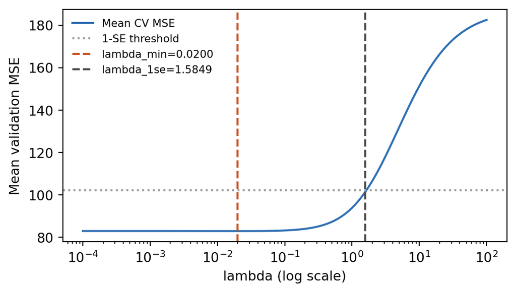

```python
import numpy as np
import pandas as pd
import matplotlib.pyplot as plt

from pathlib import Path

data_dir_candidates = [
    Path("data"),
    Path("homework/week-03/data"),
    Path("../../../data/week-03"),
]
data_dir = next(
    d for d in data_dir_candidates if (d / "realestate.csv").exists()
)

data = pd.read_csv(data_dir / "realestate.csv")
split = pd.read_csv(data_dir / "realestate-split-folds.csv")
df = data.merge(split, on="row_id")

predictor_names = ["date", "age", "distance", "stores", "latitude", "longitude"]
p = len(predictor_names)

train_mask = df["split"] == "train"
test_mask = df["split"] == "test"

X_train_all = df.loc[train_mask, predictor_names].to_numpy()
y_train_all = df.loc[train_mask, "price"].to_numpy()
fold_id = df.loc[train_mask, "cv_fold"].to_numpy()

X_test = df.loc[test_mask, predictor_names].to_numpy()
y_test = df.loc[test_mask, "price"].to_numpy()

n_train = len(y_train_all)
print(f"Training observations: {n_train}, test observations: {len(y_test)}")

# Penalty grid: {0} union {10^(-4 + 0.05*l) : l = 0, ..., 120}
lam_grid = np.concatenate(([0.0], 10 ** (-4 + 0.05 * np.arange(121))))
n_lam = len(lam_grid)


def standardize_fit(X, y):
    """Center/scale X and center y using only the fitting sample
    (variance divided by the number of fitting observations)."""
    x_bar = X.mean(axis=0)
    s = np.sqrt(((X - x_bar) ** 2).mean(axis=0))
    Xs = (X - x_bar) / s
    y_bar = y.mean()
    y_tilde = y - y_bar
    return x_bar, s, y_bar, Xs, y_tilde


def ridge_beta(Xs, y_tilde, lam, n_fit):
    return np.linalg.solve(Xs.T @ Xs + n_fit * lam * np.eye(Xs.shape[1]), Xs.T @ y_tilde)


def predict(X_new, x_bar, s, y_bar, beta_hat):
    return y_bar + ((X_new - x_bar) / s) @ beta_hat

n_folds = 10
fold_mse = np.empty((n_folds, n_lam))

for f in range(1, n_folds + 1):
    fit_mask = fold_id != f
    val_mask = fold_id == f

    X_fit, y_fit = X_train_all[fit_mask], y_train_all[fit_mask]
    X_val, y_val = X_train_all[val_mask], y_train_all[val_mask]
    n_fit = len(y_fit)

    x_bar, s, y_bar, Xs_fit, y_tilde_fit = standardize_fit(X_fit, y_fit)

    for j, lam in enumerate(lam_grid):
        beta_hat = ridge_beta(Xs_fit, y_tilde_fit, lam, n_fit)
        pred_val = predict(X_val, x_bar, s, y_bar, beta_hat)
        fold_mse[f - 1, j] = np.mean((y_val - pred_val) ** 2)

mean_mse = fold_mse.mean(axis=0)
se_mse = fold_mse.std(axis=0, ddof=1) / np.sqrt(n_folds)

idx_min = int(np.argmin(mean_mse))
lambda_min = lam_grid[idx_min]
one_se_limit = mean_mse[idx_min] + se_mse[idx_min]

# Largest lambda in the grid (including OLS) whose mean CV MSE is
# still within one SE of the minimum.
eligible = lam_grid[mean_mse <= one_se_limit]
lambda_1se = eligible.max()

print("\n=== Part (a) ===")
print(f"lambda_min = {lambda_min:.6f}  (mean CV MSE = {mean_mse[idx_min]:.4f}, SE = {se_mse[idx_min]:.4f})")
print(f"one-SE threshold = {one_se_limit:.4f}")
print(f"lambda_1se = {lambda_1se:.6f}")

plt.figure(figsize=(5.5, 3.2))
plt.plot(lam_grid[1:], mean_mse[1:], color="#2F6FB3", label="Mean CV MSE")
plt.axhline(one_se_limit, color="0.6", linestyle=":", label="1-SE threshold")
plt.axvline(lambda_min, color="#C84A16", linestyle="--", label=f"lambda_min={lambda_min:.4f}")
plt.axvline(lambda_1se, color="0.3", linestyle="--", label=f"lambda_1se={lambda_1se:.4f}")
plt.xscale("log")
plt.xlabel("lambda (log scale)")
plt.ylabel("Mean validation MSE")
plt.legend(frameon=False, fontsize=8)
plt.tight_layout()
plt.savefig("q5_cv_plot.png", dpi=150)
```

Sweeping λ over the grid using the supplied fold labels (re-standardizing predictors from only the 9 fitting folds each time) gives λ_min = 0.01995 (mean CV MSE = 82.978, SE = 19.23). The one-SE threshold is 82.978+19.23 = 102.208, and the largest λ in the grid (including OLS) still under that threshold is λ_1se = 1.58489 — a much stronger penalty, because the fold-to-fold noise is large enough that a wide range of λ’s are “statistically indistinguishable” from the minimum.

**Show the workflow**

```
=== Part (b) ===
lambda_gcv = 0.028184  (GCV = 83.5019, df_eff = 6.689)
```

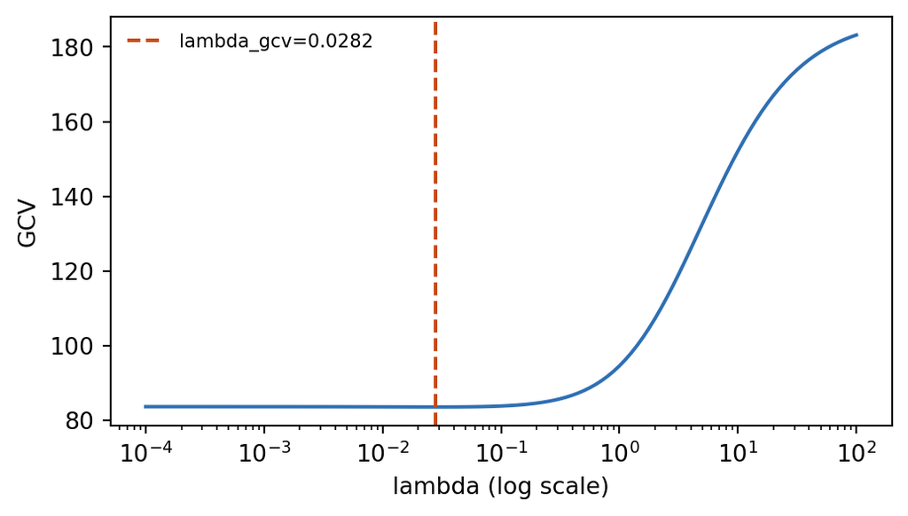

```python
x_bar_all, s_all, y_bar_all, Xs_all, y_tilde_all = standardize_fit(X_train_all, y_train_all)
singular_values = np.linalg.svd(Xs_all, compute_uv=False)

gcv = np.empty(n_lam)
train_mse_grid = np.empty(n_lam)
df_eff_grid = np.empty(n_lam)

for j, lam in enumerate(lam_grid):
    beta_hat = ridge_beta(Xs_all, y_tilde_all, lam, n_train)
    resid = y_tilde_all - Xs_all @ beta_hat
    train_mse_grid[j] = np.mean(resid ** 2)
    df_eff_grid[j] = 1 + np.sum(singular_values ** 2 / (singular_values ** 2 + n_train * lam))
    gcv[j] = train_mse_grid[j] / (1 - df_eff_grid[j] / n_train) ** 2

idx_gcv = int(np.argmin(gcv))
lambda_gcv = lam_grid[idx_gcv]

print("\n=== Part (b) ===")
print(f"lambda_gcv = {lambda_gcv:.6f}  (GCV = {gcv[idx_gcv]:.4f}, df_eff = {df_eff_grid[idx_gcv]:.3f})")

plt.figure(figsize=(5.5, 3.2))
plt.plot(lam_grid[1:], gcv[1:], color="#2F6FB3")
plt.axvline(lambda_gcv, color="#C84A16", linestyle="--", label=f"lambda_gcv={lambda_gcv:.4f}")
plt.xscale("log")
plt.xlabel("lambda (log scale)")
plt.ylabel("GCV")
plt.legend(frameon=False, fontsize=8)
plt.tight_layout()
plt.savefig("q5_gcv_plot.png", dpi=150)
```

Using all 332 training rows once (fixed standardization), GCV is minimized at λ_GCV = 0.02818, very close to λ_min — both pick mild shrinkage.

**Show the workflow**

```python
rules = {
    "OLS": 0.0,
    "CV minimum": lambda_min,
    "One SE": lambda_1se,
    "GCV": lambda_gcv,
}

print("\n=== Part (c) ===")
print(f"{'rule':<12}{'lambda':>10}{'df_eff':>10}{'train_mse':>12}{'test_mse':>12}")
for name, lam in rules.items():
    beta_hat = ridge_beta(Xs_all, y_tilde_all, lam, n_train)
    train_pred = y_bar_all + Xs_all @ beta_hat
    test_pred = predict(X_test, x_bar_all, s_all, y_bar_all, beta_hat)

    train_mse = np.mean((y_train_all - train_pred) ** 2)
    test_mse = np.mean((y_test - test_pred) ** 2)
    df_eff = 1 + np.sum(singular_values ** 2 / (singular_values ** 2 + n_train * lam))

    print(f"{name:<12}{lam:10.5f}{df_eff:10.3f}{train_mse:12.3f}{test_mse:12.3f}")

print("\nsaved q5_cv_plot.png and q5_gcv_plot.png")
```

```
=== Part (c) ===
rule            lambda    df_eff   train_mse    test_mse
OLS            0.00000     7.000      80.094      66.322
CV minimum     0.01995     6.773      80.135      66.000
One SE         1.58489     3.033     100.374      81.200
GCV            0.02818     6.689      80.171      65.903

saved q5_cv_plot.png and q5_gcv_plot.png
```

OLS has the smallest training MSE, as expected — it’s the least constrained fit. CV-minimum and GCV use only mild shrinkage (effective df ≈ 6.7–6.8, barely below OLS’s 7) and land within a hair of each other on test MSE (66.0 vs 65.9). The one-SE rule imposes much stronger regularization, cutting effective df to about 3.0, and that extra bias costs it here — test MSE jumps to 81.2, worse than all three other choices on this particular test set.

Why you still can’t just pick the model with the smallest observed test MSE (GCV, 65.903) after seeing this table: all three λ’s were fixed using only training information, so this test evaluation is a valid one-shot check of each procedure. But if you now went back and picked GCV specifically because it happened to win this table, you’d be using the test set to select a model — exactly the mistake from Question 5 of Week 2. The test set can validate a decision made in advance; it can’t be used to make that decision after the fact. Also worth noting: GCV isn’t an independent check either — it estimates test error from training residuals adjusted by effective degrees of freedom, not from held-out data. And none of these penalty choices can fix problems ridge doesn’t address at all — nonlinearity, omitted variables, or other misspecification — they only control coefficient variance within the linear model as given.

# Reference

The real-estate data come from I-Cheng Yeh’s [Real Estate Valuation dataset](https://archive.ics.uci.edu/dataset/477/real%2Bestate%2Bvaluation%2Bda) in the UCI Machine Learning Repository. The distributed data retain the original observations and add only the course train-test and fold assignments.

## `explain-to-me` skill

```markdown
---
name: explain-to-me
description: Explain a homework question's goal and requirements without solving it. Only use this when explicitly asked, e.g. "use explain-to-me to explain Question 2." Do not use it to check formatting or grade work.
---

Intent: help the student understand what a homework question is asking so they can solve it themselves. Never do the solving for them.

When asked to explain a homework question:

1. Read only the target question (and any shared setup/notation immediately above it that the question depends on).
2. Respond using exactly these sections:
   - **Goal**: one or two sentences on what the question is really testing.
   - **What you need to produce**: the concrete deliverables (e.g. a specific plot, a derivation, particular reported numbers).
   - **Key setup/assumptions**: notation or given quantities the student must use, restated plainly.
   - **Relevant lecture**: point to whichever is more relevant, with a subsection if possible:
     - [Ridge Regression: Stability Through Shrinkage](https://teazrq.github.io/stat432rpy/topics/ridge-regression/ridge-regression.html)
     - [From a Penalized Objective to a Fitted Ridge Model](https://teazrq.github.io/stat432rpy/topics/ridge-regression/optimization-and-cross-validation.html)
3. Do NOT provide the solution, code, derivation steps, or numeric answers. Do not introduce formulas beyond what the question already gives.
4. If the question has sub-parts (a, b, c, ...), address each sub-part briefly under the same sections rather than solving any of them.
5. Keep the whole response under ~200 words unless the student explicitly asks for more detail.
```